# Non-normal covariates: heavy tails and skew

### gamma(2)

#### unknown variance

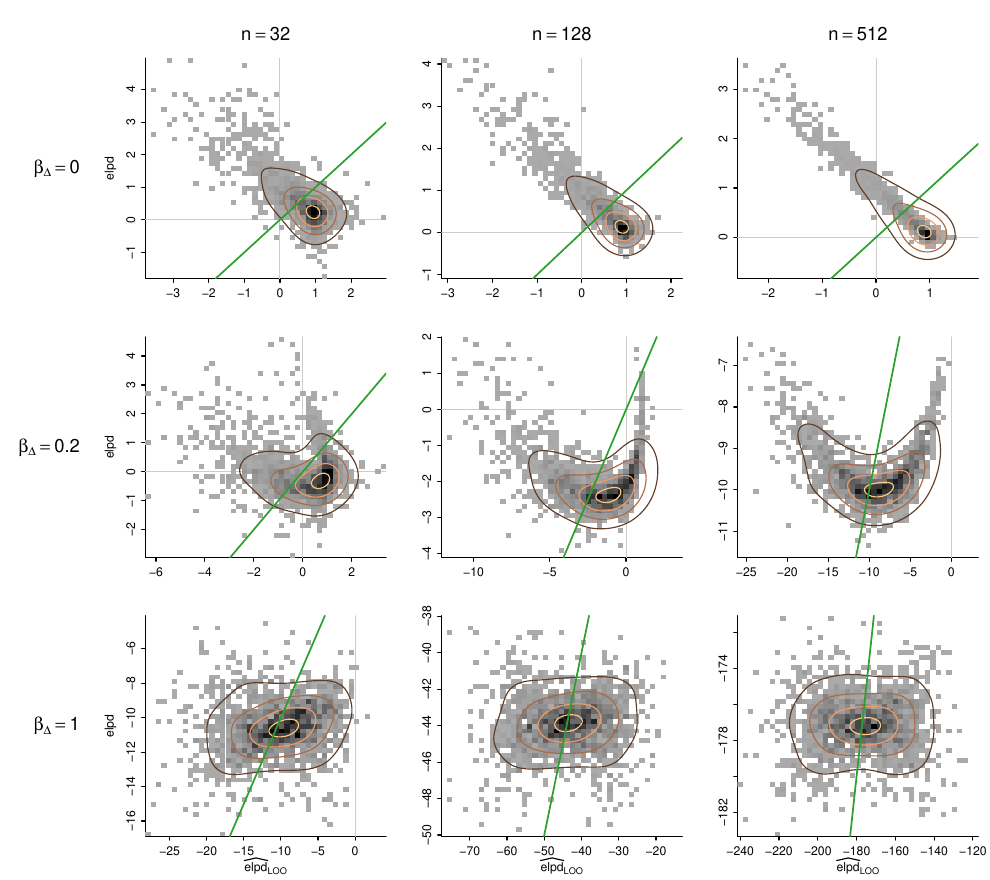

#### known variance (τ² = 1)

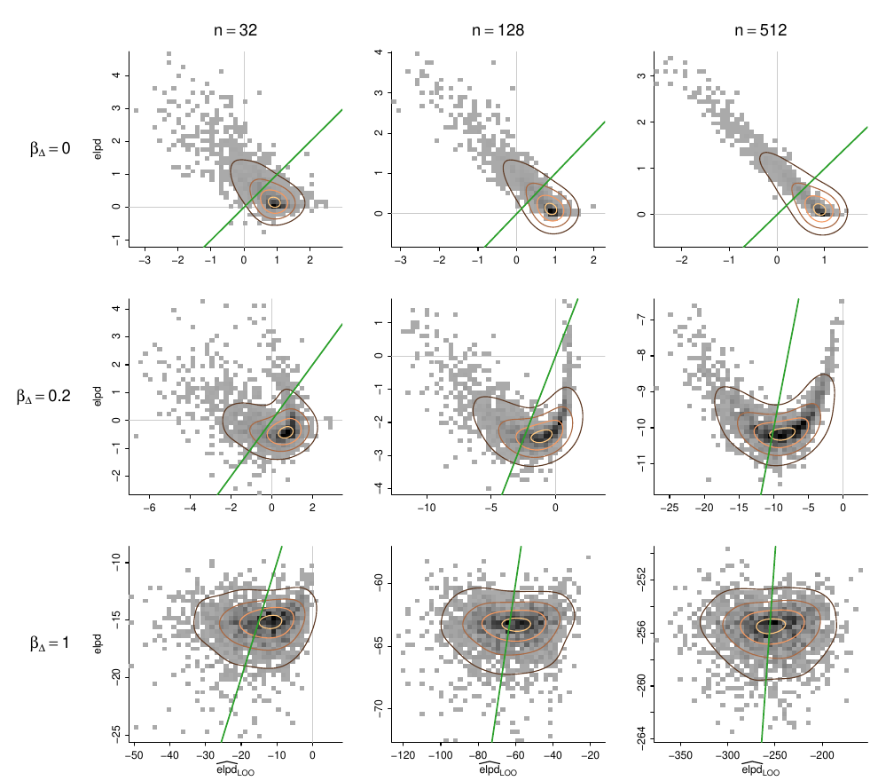

## Joint distribution by the variance

The joint distribution as points. The colour is the quantile of $\overline{x_2^2}$ of the training set, inside the cell. Model A puts $\beta_t x_2$ into its noise, so $\hat\tau^2_A \approx 1 + \beta_t^2 \overline{x_2^2}$. The LOO estimate and the target both contain $-\tfrac{n}{2} \log \hat\tau^2_A$. So a large $\overline{x_2^2}$ moves the trial down the diagonal when $\beta_t > 0$. The red line is the diagonal.

### normal

#### unknown variance

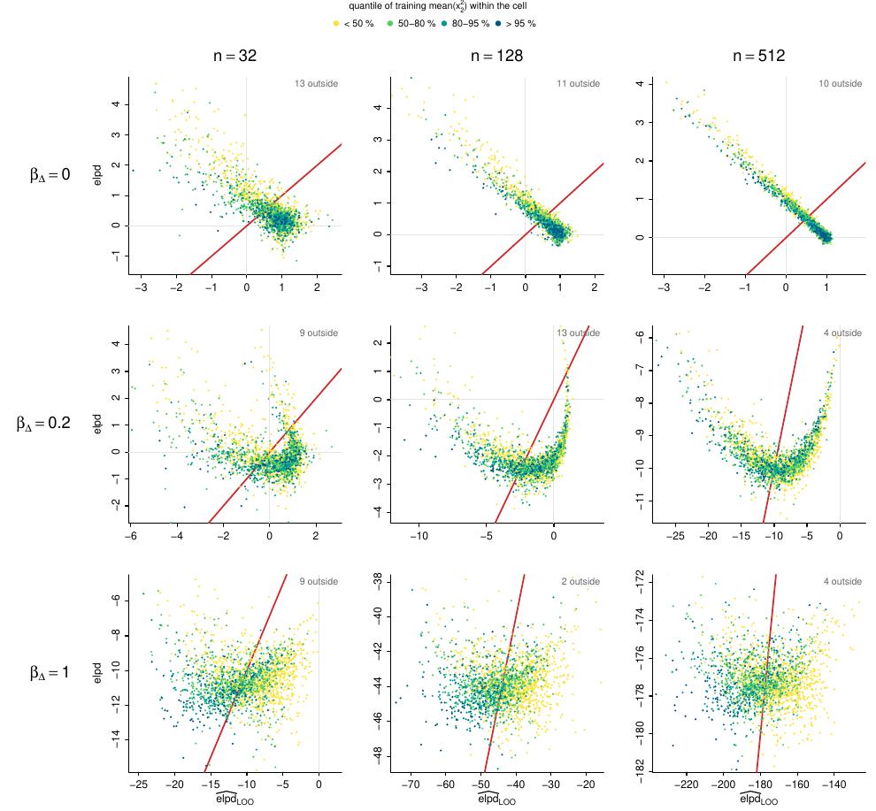

#### known variance (τ² = 1)

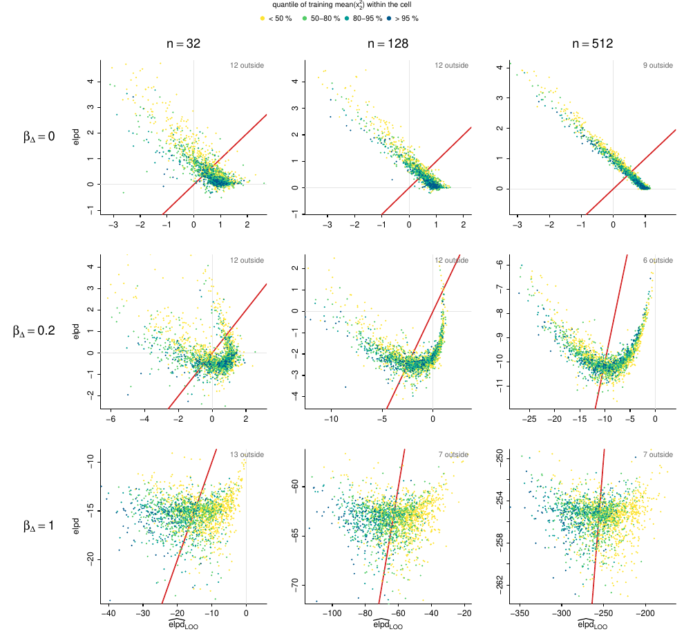

### t(30)

#### unknown variance

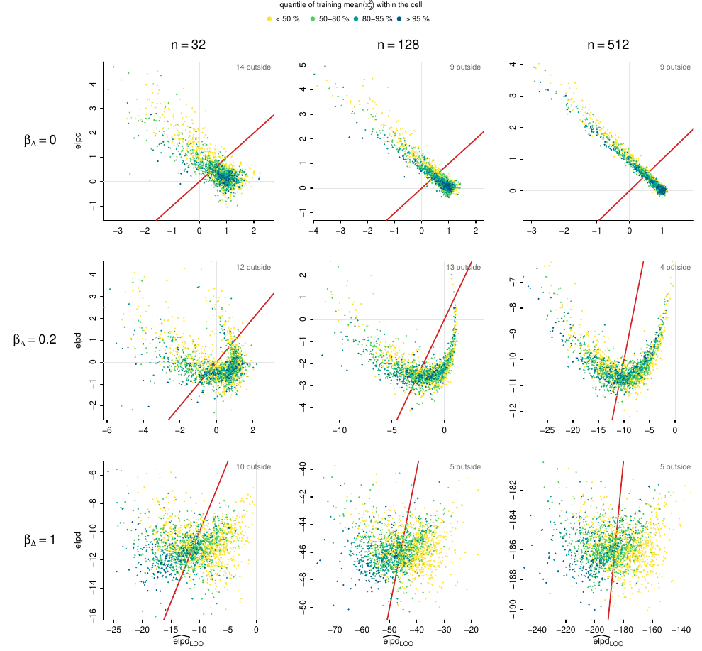

#### known variance (τ² = 1)

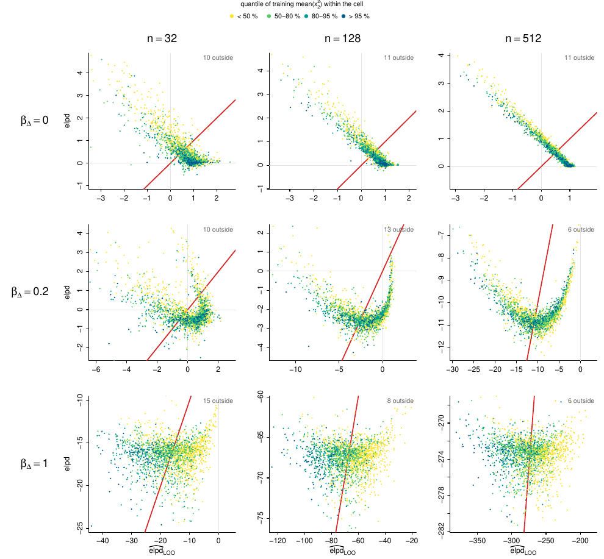

### t(10)

#### unknown variance

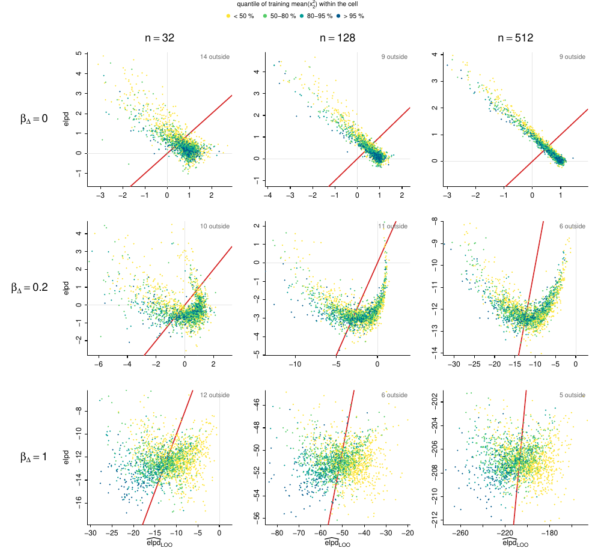

#### known variance (τ² = 1)

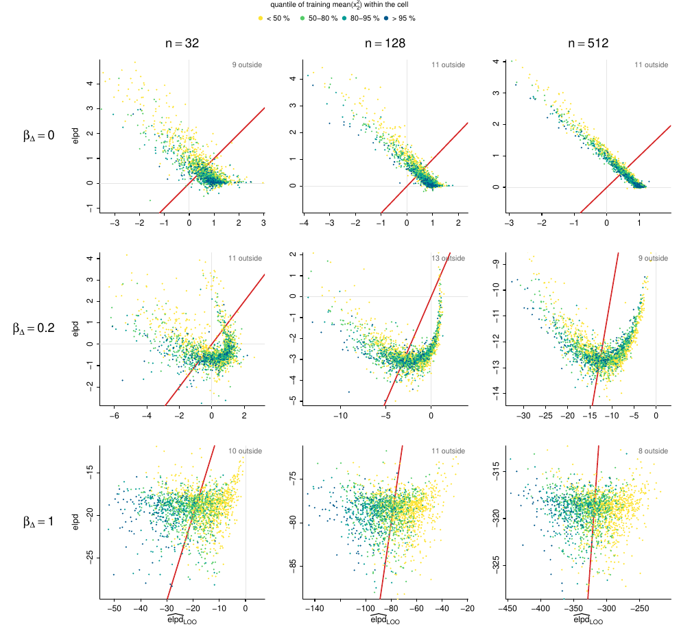

### t(5)

#### unknown variance

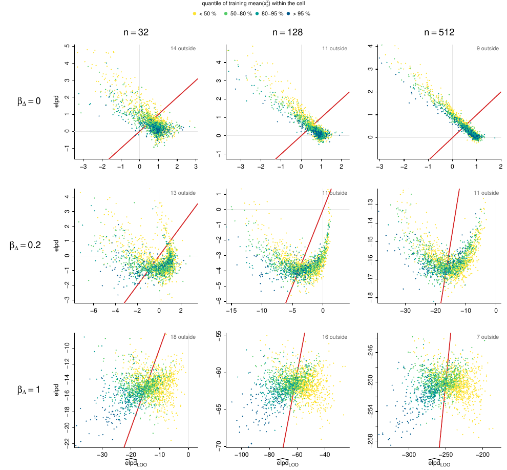

#### known variance (τ² = 1)

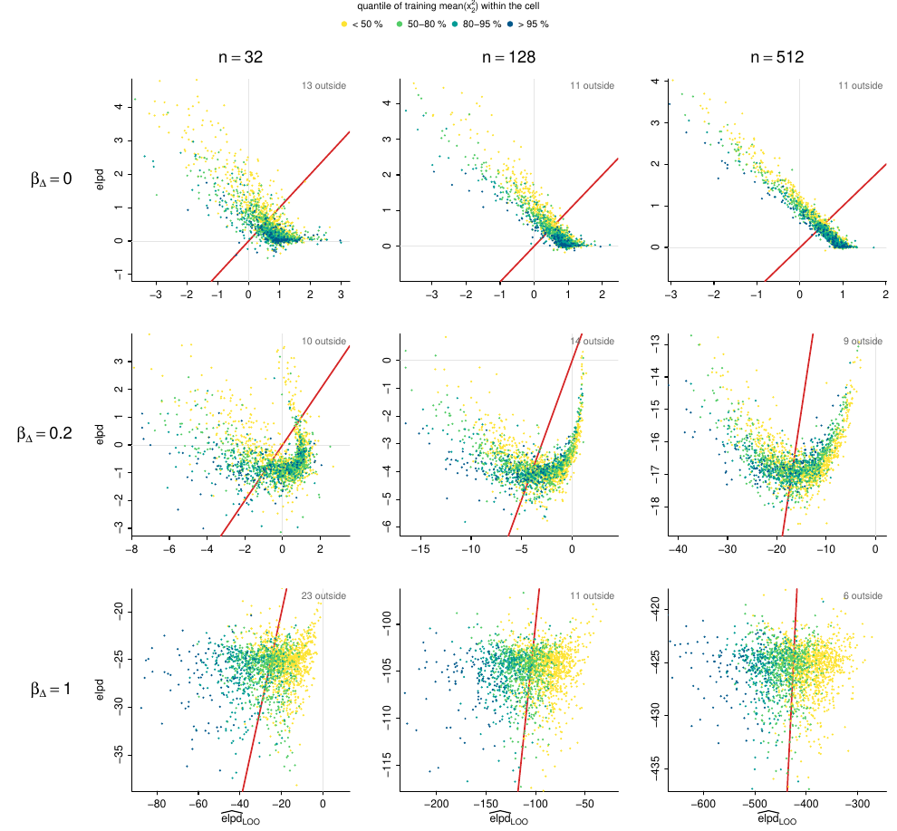

### t(3)

#### unknown variance

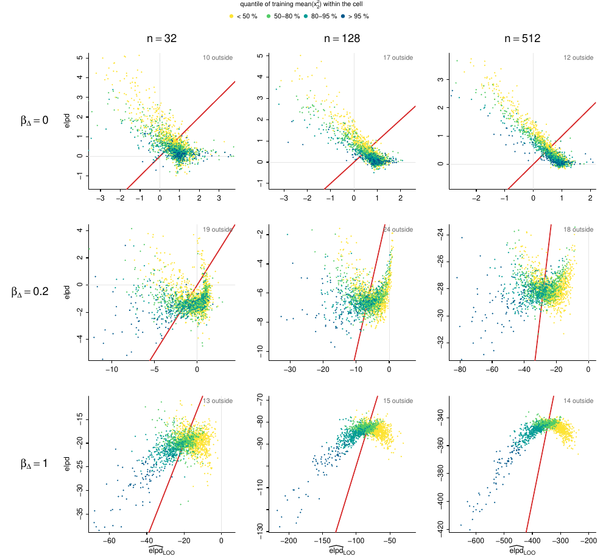

#### known variance (τ² = 1)

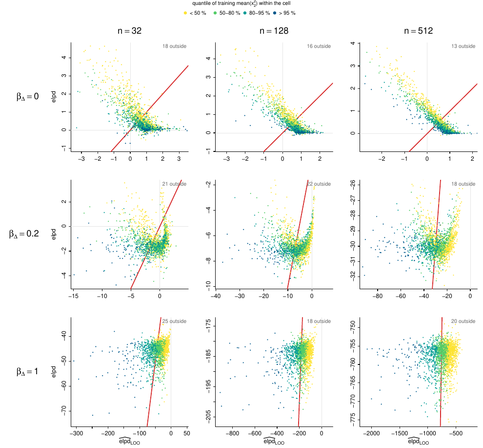

### t(1)

#### unknown variance

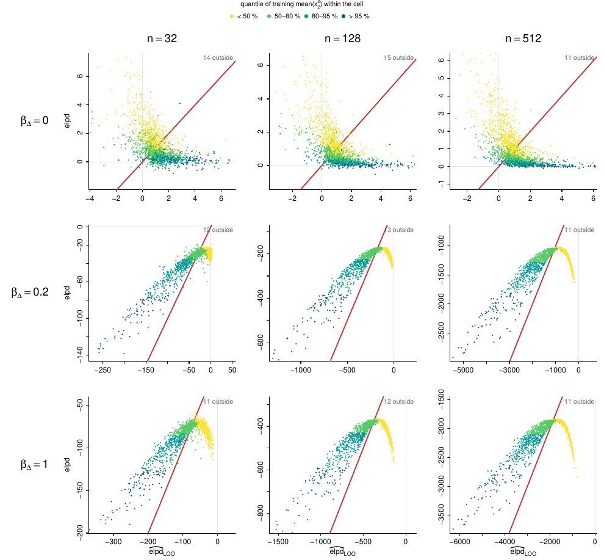

#### known variance (τ² = 1)

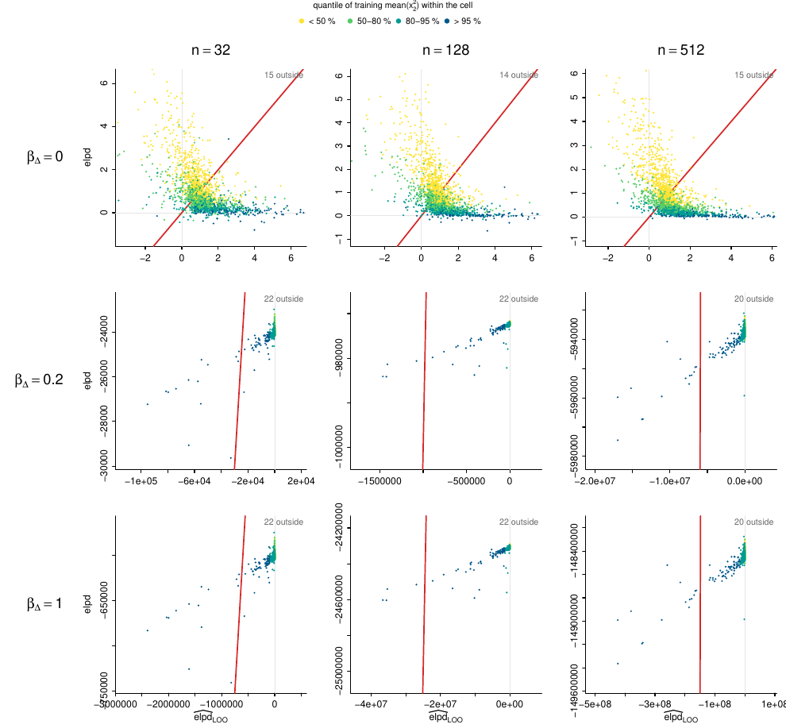

### skew-t(5)

#### unknown variance

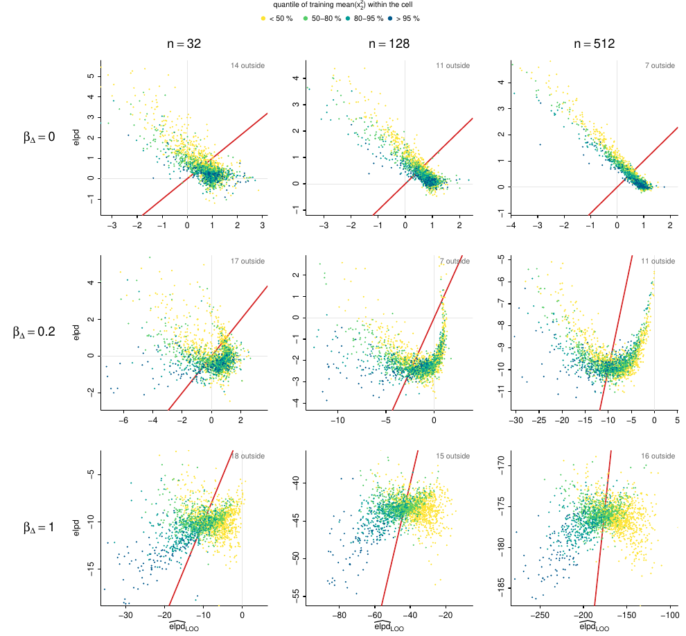

#### known variance (τ² = 1)

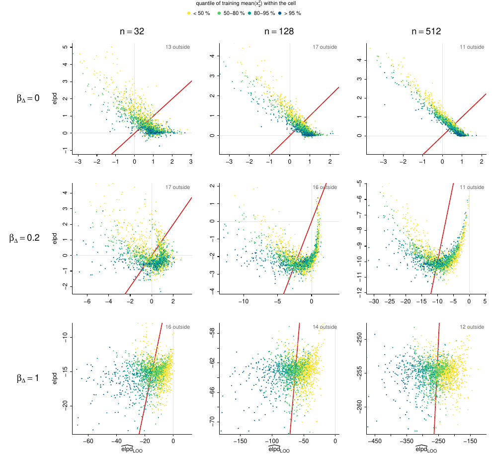

### gamma(2)

#### unknown variance

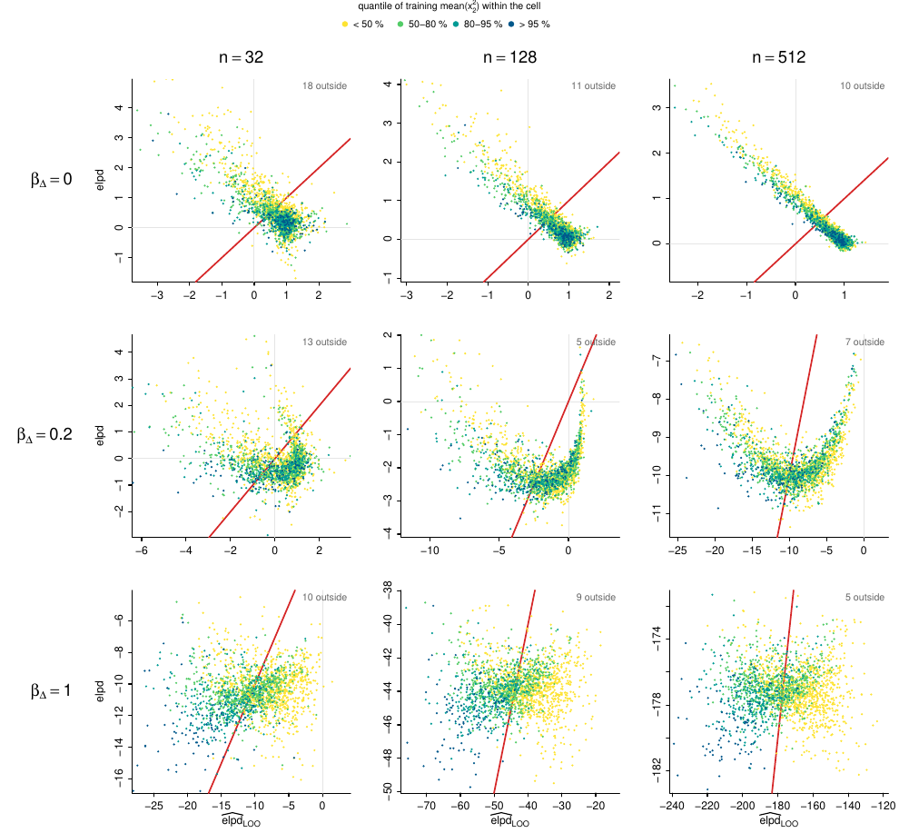

#### known variance (τ² = 1)

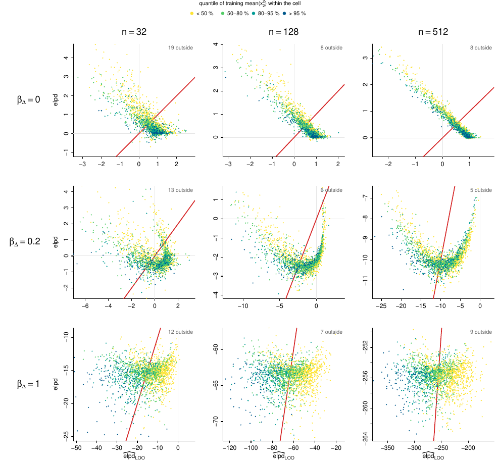

## Moments

Mean/SD and skewness of the estimate, the target and the error against $n$, without the outlier, as Fig. 9 of the paper. Bands are 95 % Bayesian-bootstrap intervals.

### normal

#### unknown variance

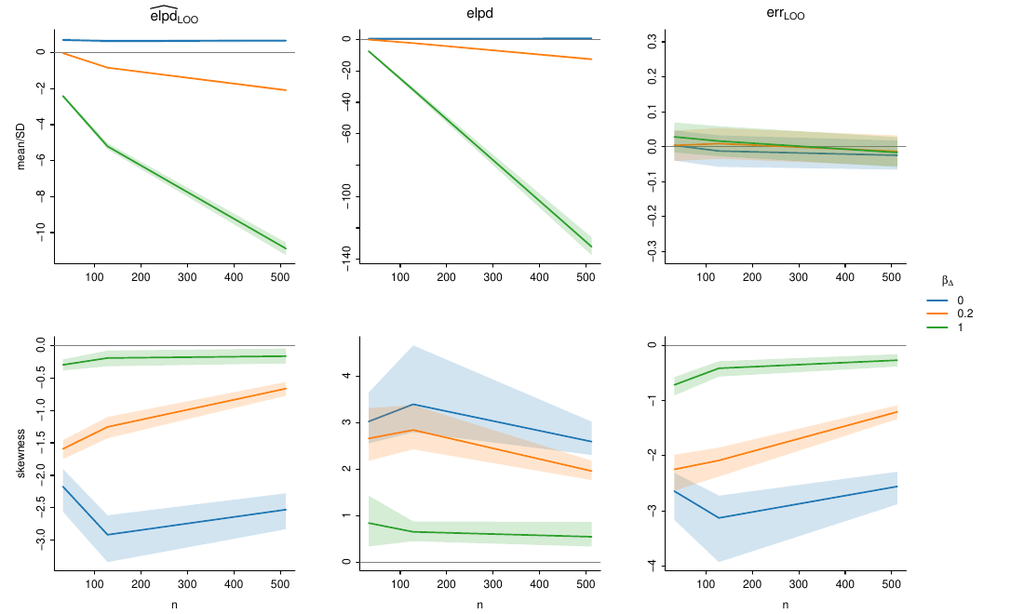

#### known variance (τ² = 1)

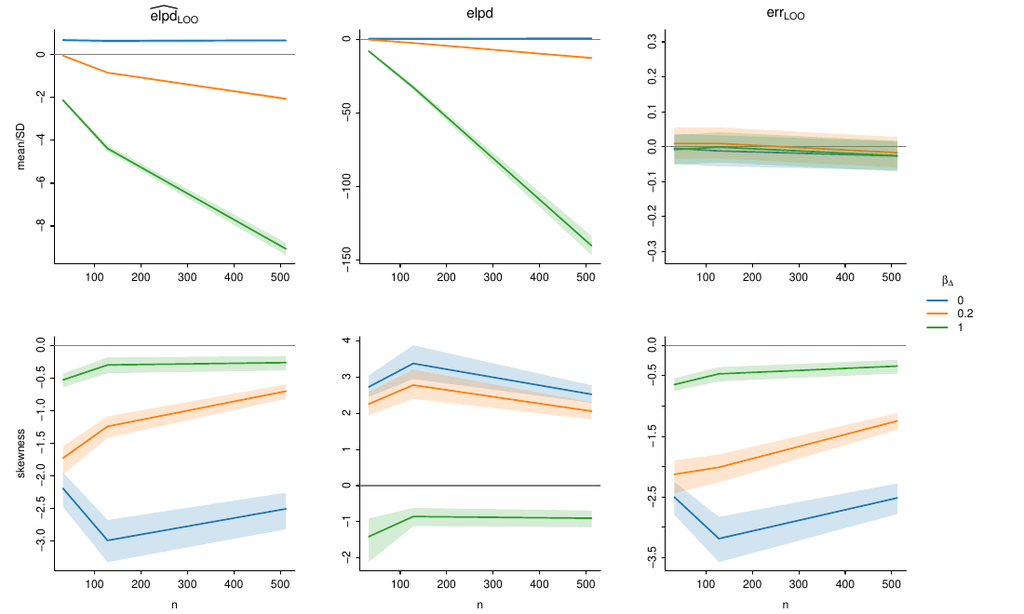

### t(30)

#### unknown variance

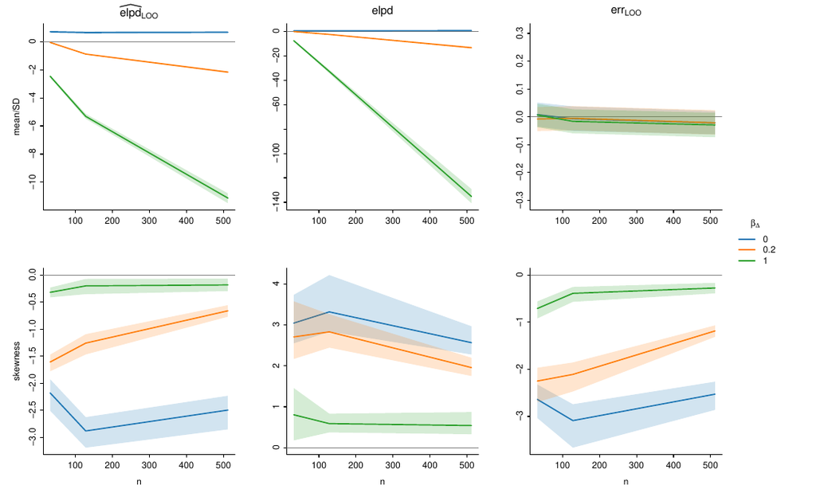

#### known variance (τ² = 1)

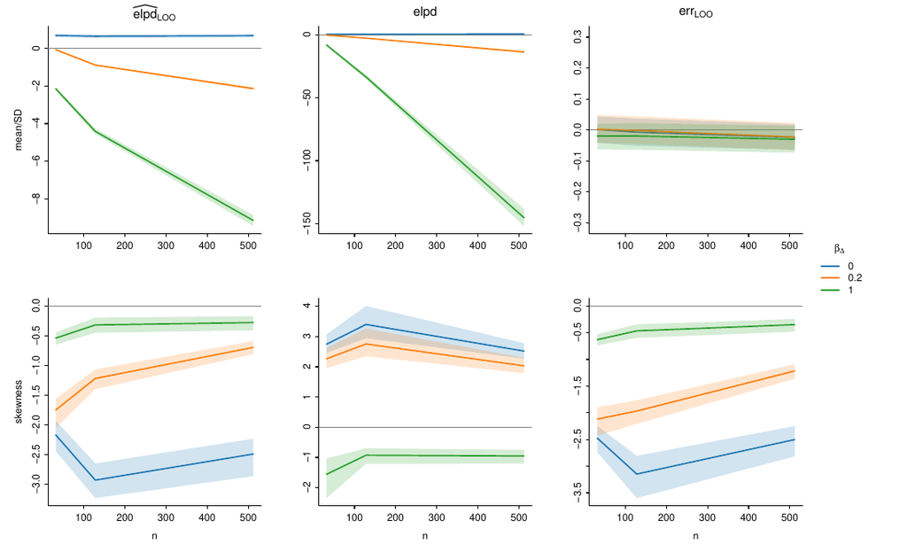

### t(10)

#### unknown variance

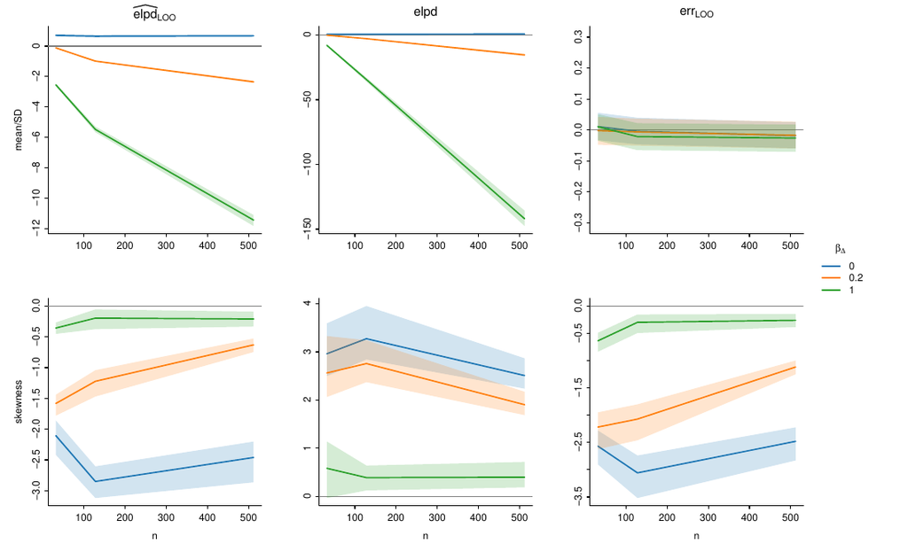

#### known variance (τ² = 1)

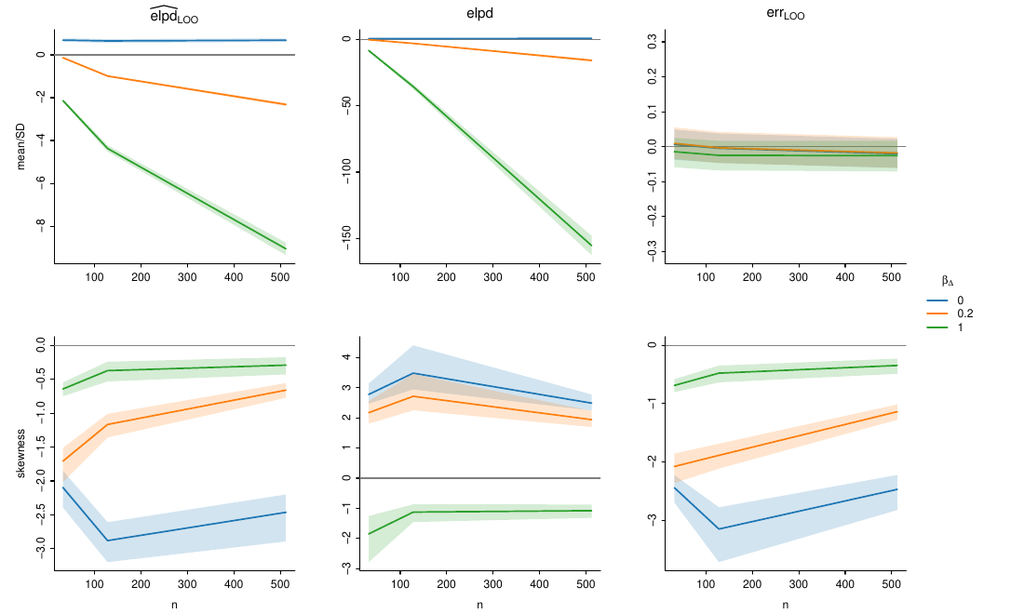

### t(5)

#### unknown variance

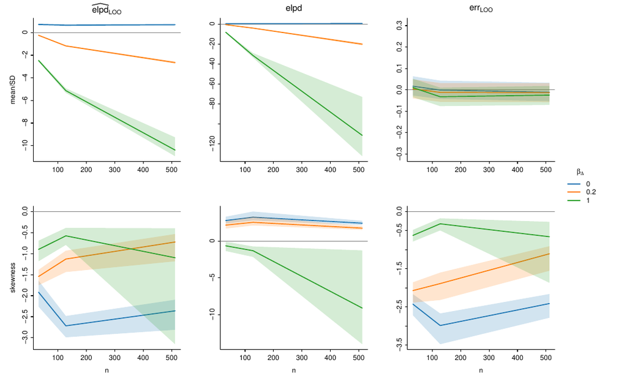

#### known variance (τ² = 1)

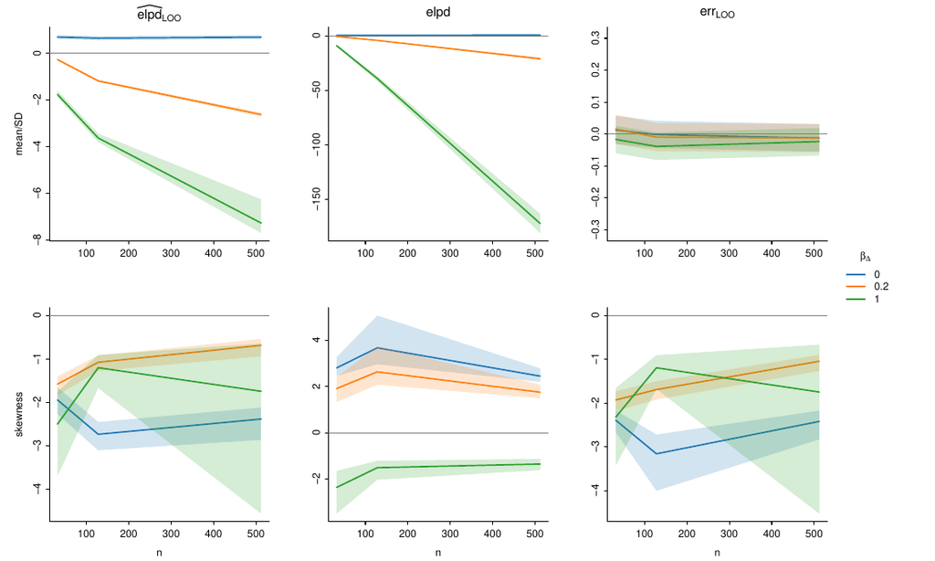

### t(3)

#### unknown variance

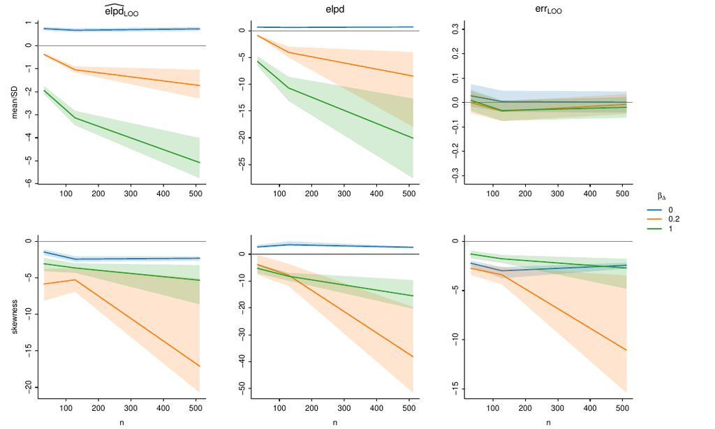

#### known variance (τ² = 1)

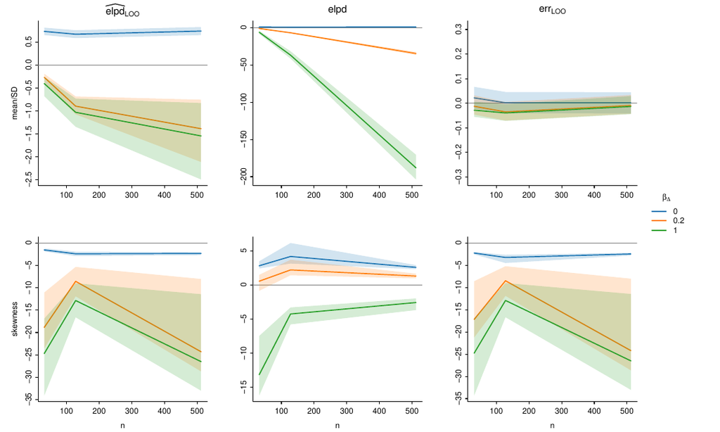

### t(1)

#### unknown variance

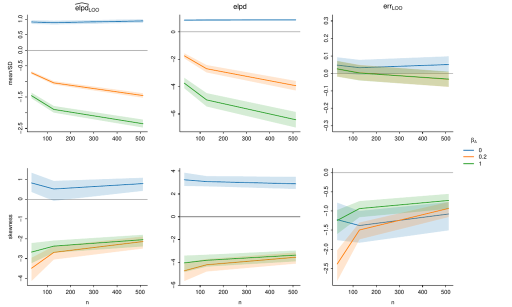

#### known variance (τ² = 1)

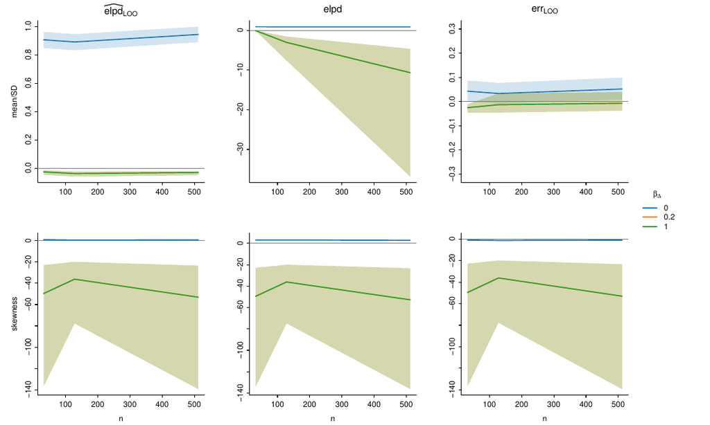

### skew-t(5)

#### unknown variance

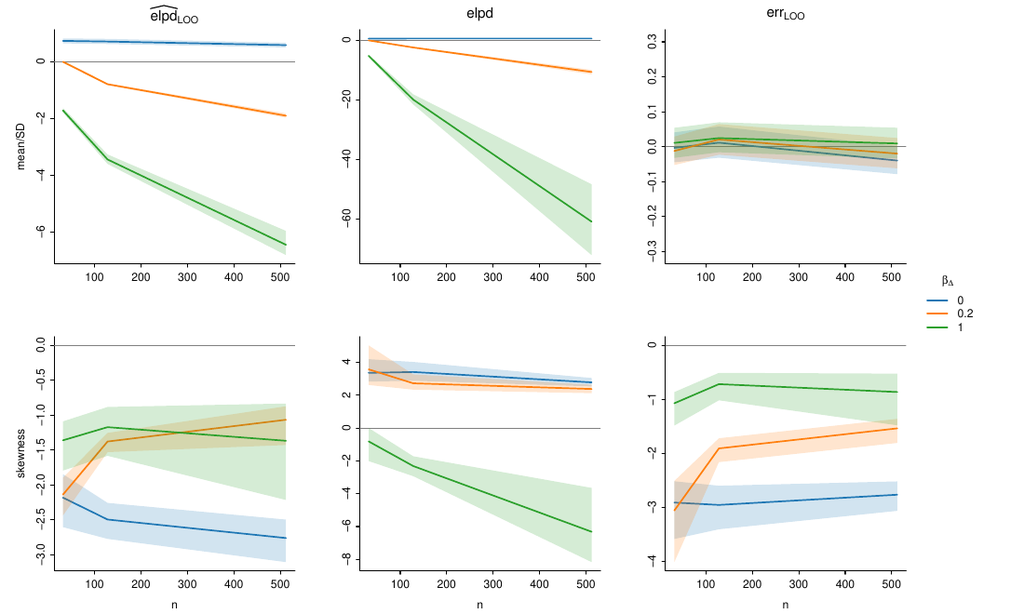

#### known variance (τ² = 1)

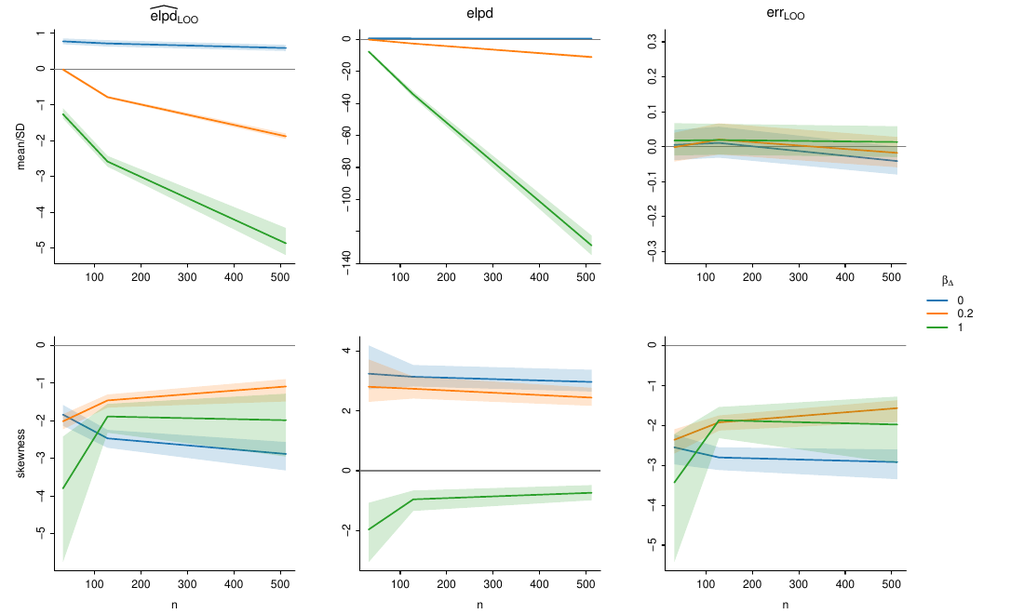

### gamma(2)

#### unknown variance

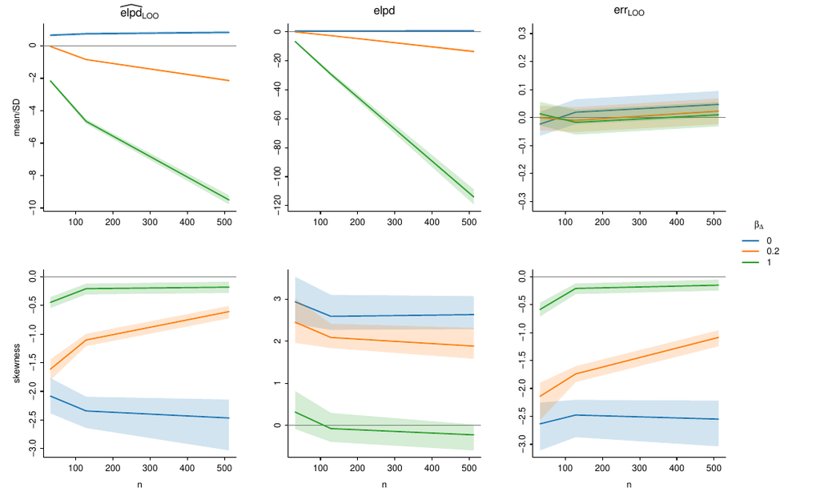

#### known variance (τ² = 1)

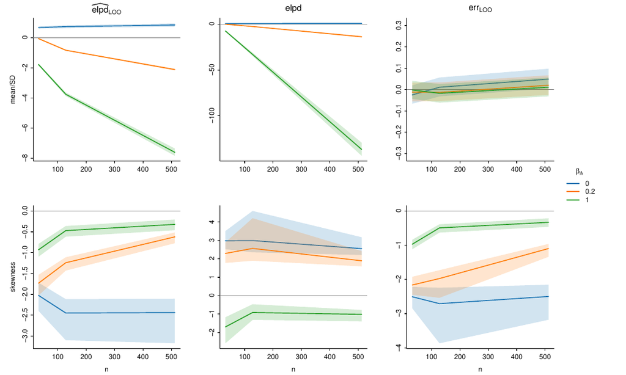

## SE ratio

The stated SE divided by the actual SD of the LOO error, without the outlier, as `simulated/plot_all__var_ratioi_n_b.py`. A ratio below 1 means that the SE is too small.

### normal

#### unknown variance

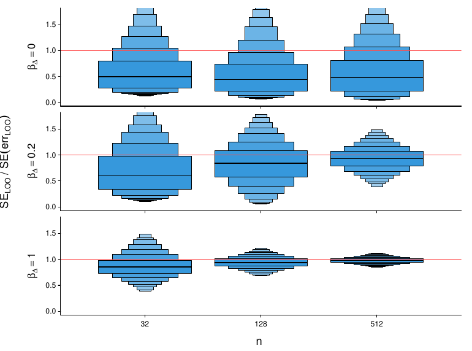

#### known variance (τ² = 1)

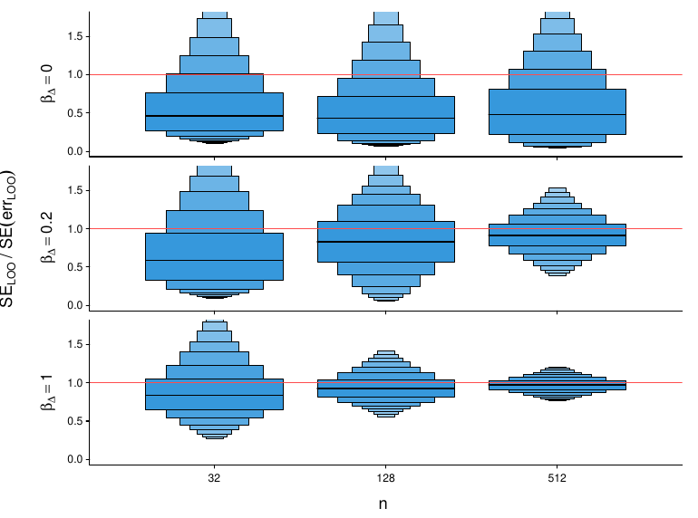

### t(30)

#### unknown variance

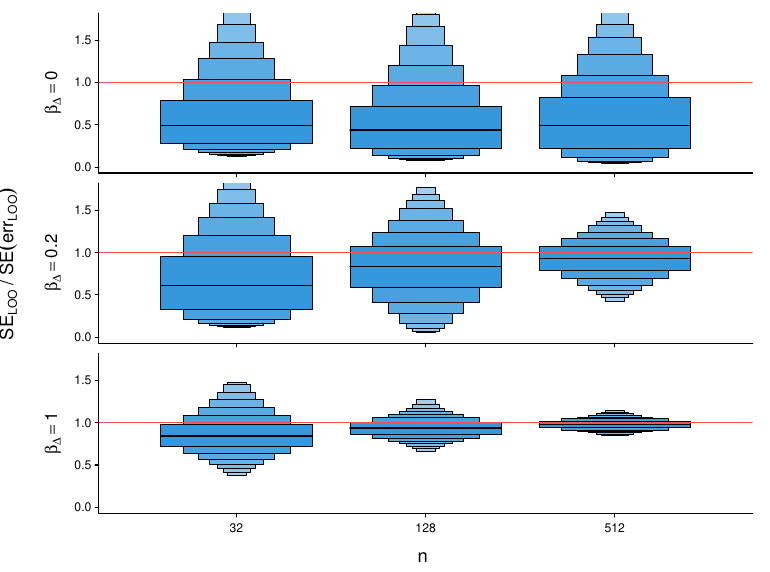

#### known variance (τ² = 1)

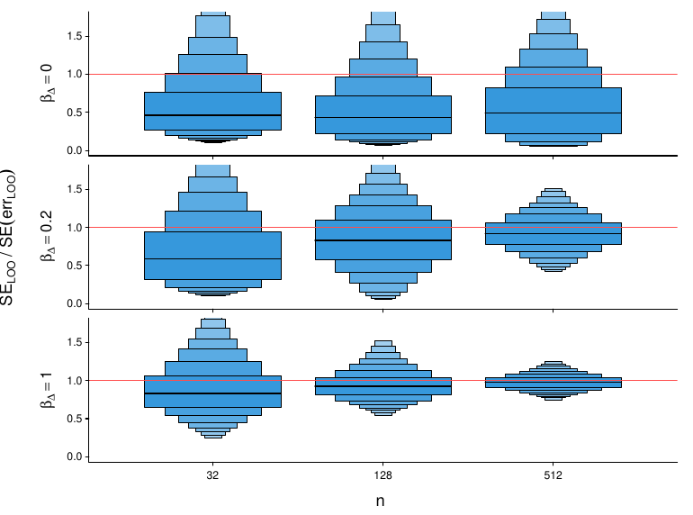

### t(10)

#### unknown variance

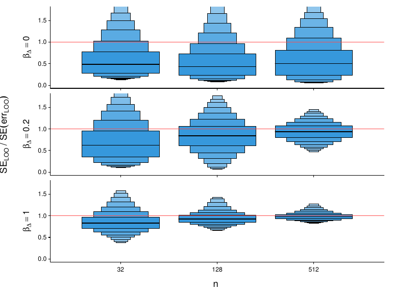

#### known variance (τ² = 1)

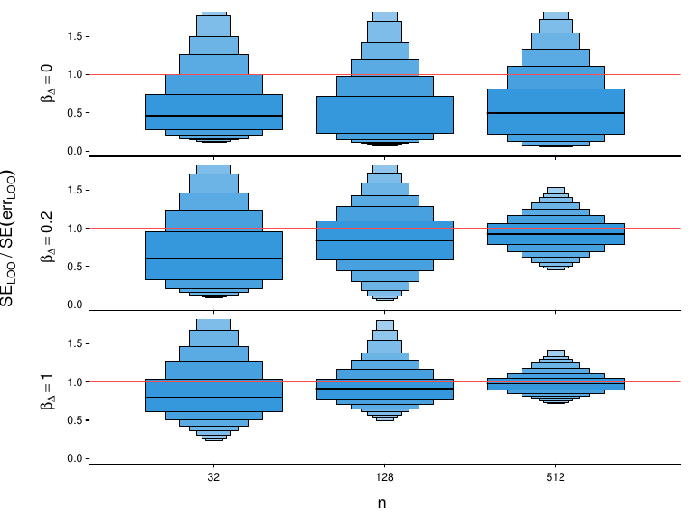

### t(5)

#### unknown variance

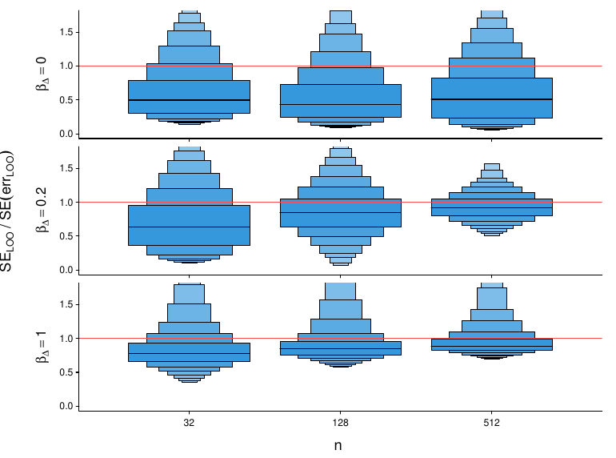

#### known variance (τ² = 1)

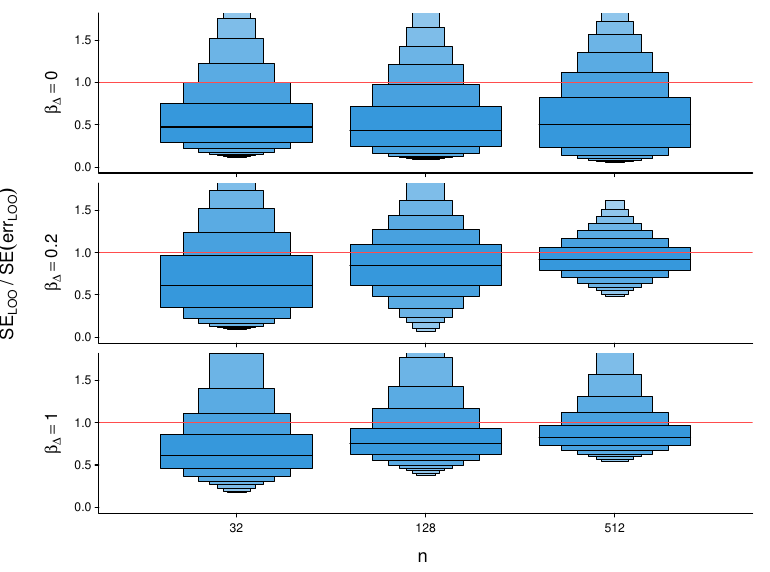

### t(3)

#### unknown variance

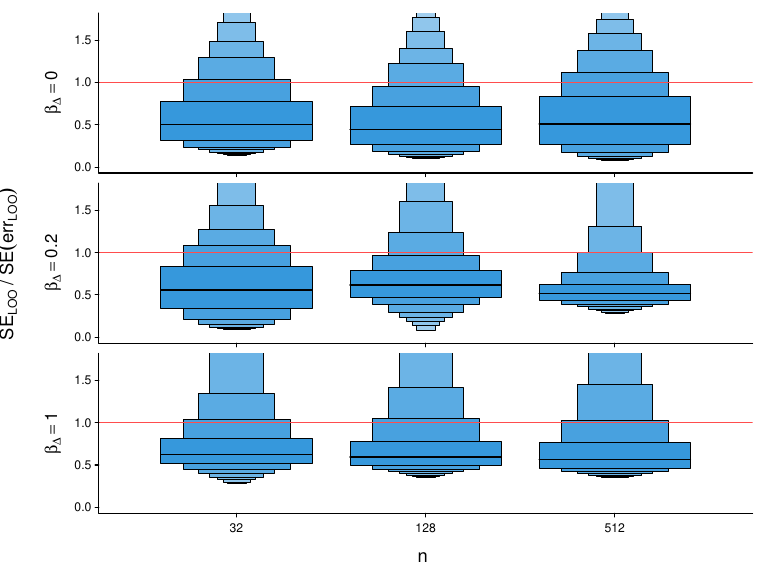

#### known variance (τ² = 1)

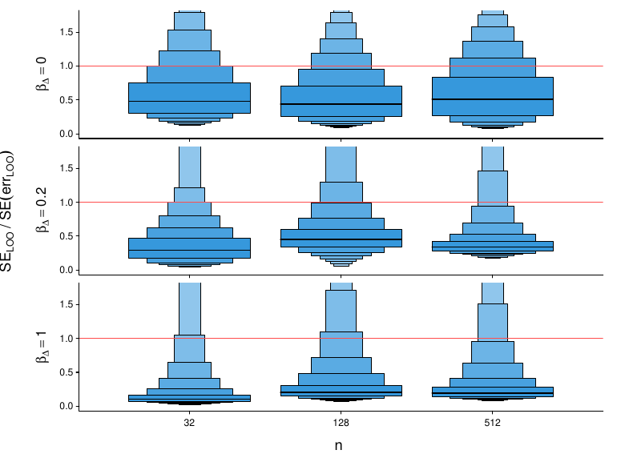

### t(1)

#### unknown variance

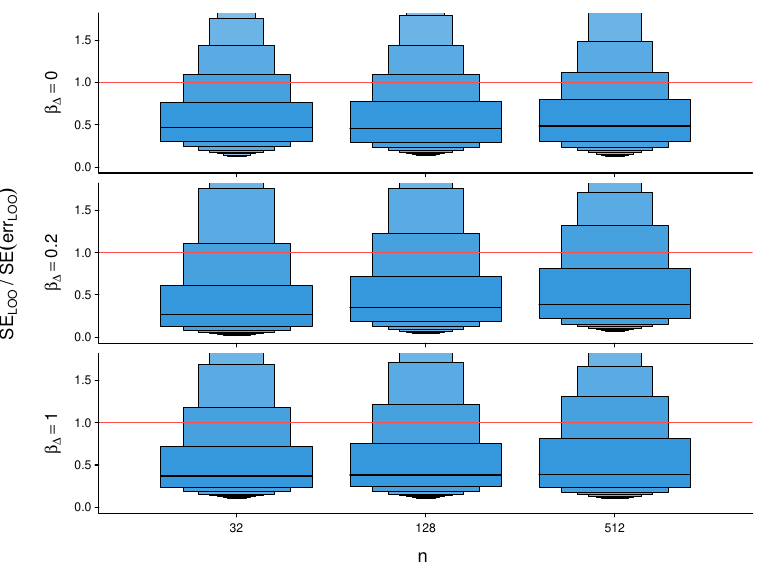

#### known variance (τ² = 1)

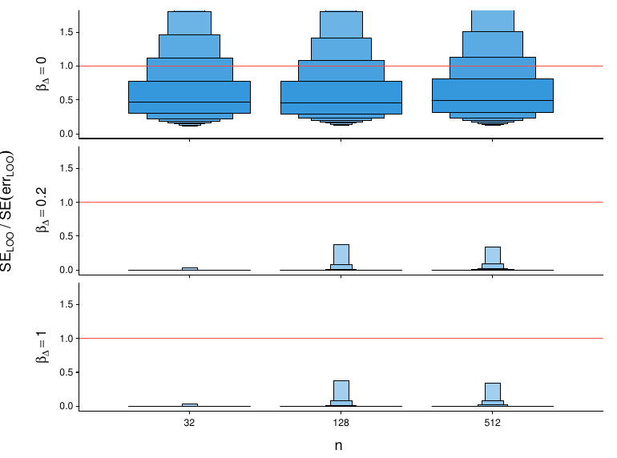

### skew-t(5)

#### unknown variance

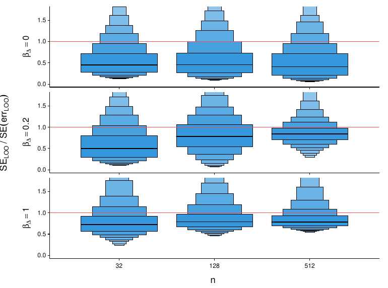

#### known variance (τ² = 1)

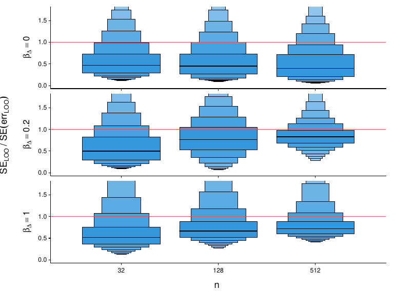

### gamma(2)

#### unknown variance

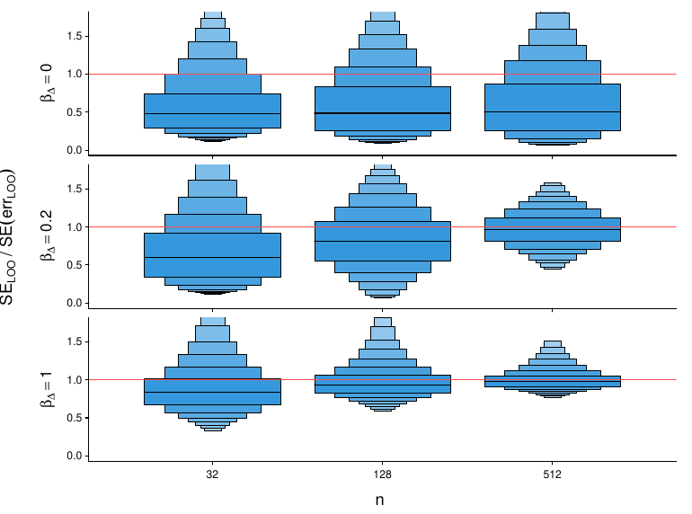

#### known variance (τ² = 1)

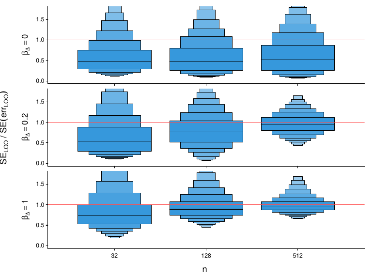

## Error

The LOO error in units of its own SD, as `simulated/plot_all__err_n_b_both.py`. The short line is the mean.

### normal

#### unknown variance

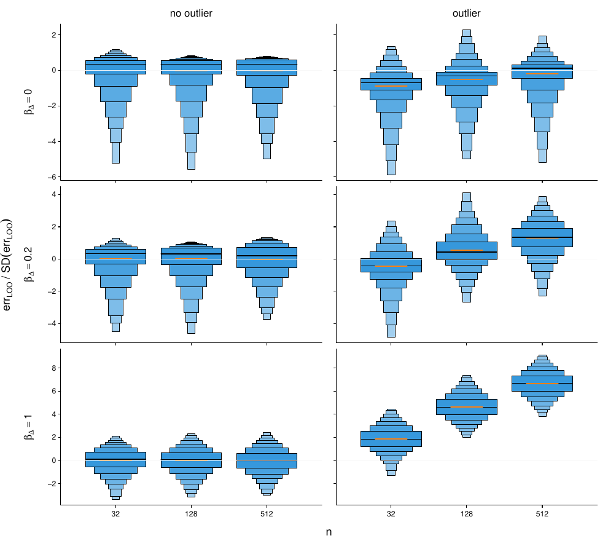

#### known variance (τ² = 1)

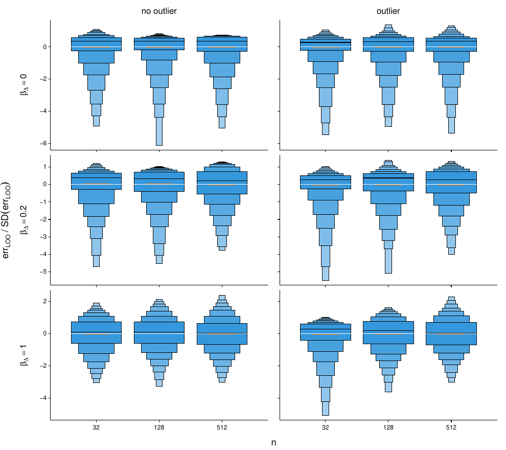

### t(30)

#### unknown variance

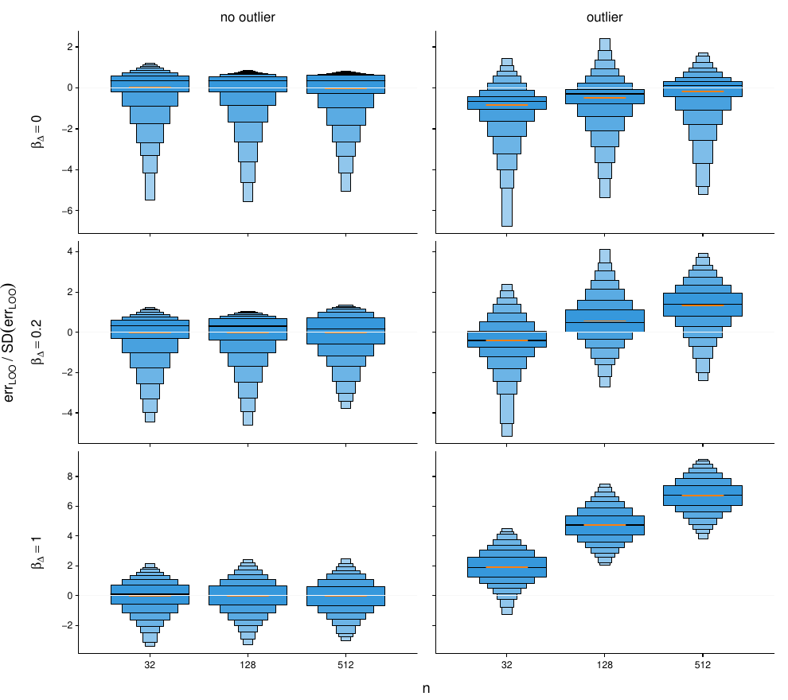

#### known variance (τ² = 1)

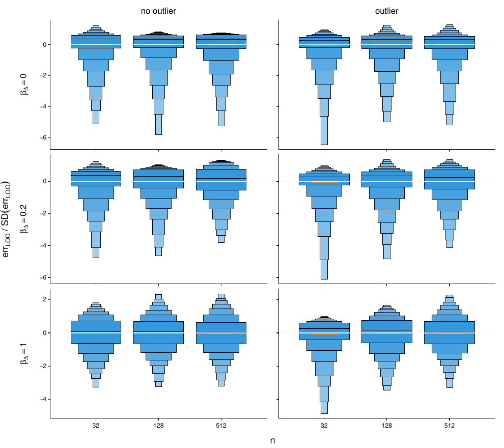

### t(10)

#### unknown variance

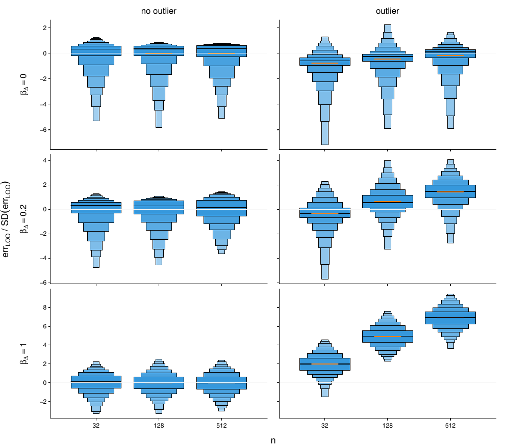

#### known variance (τ² = 1)

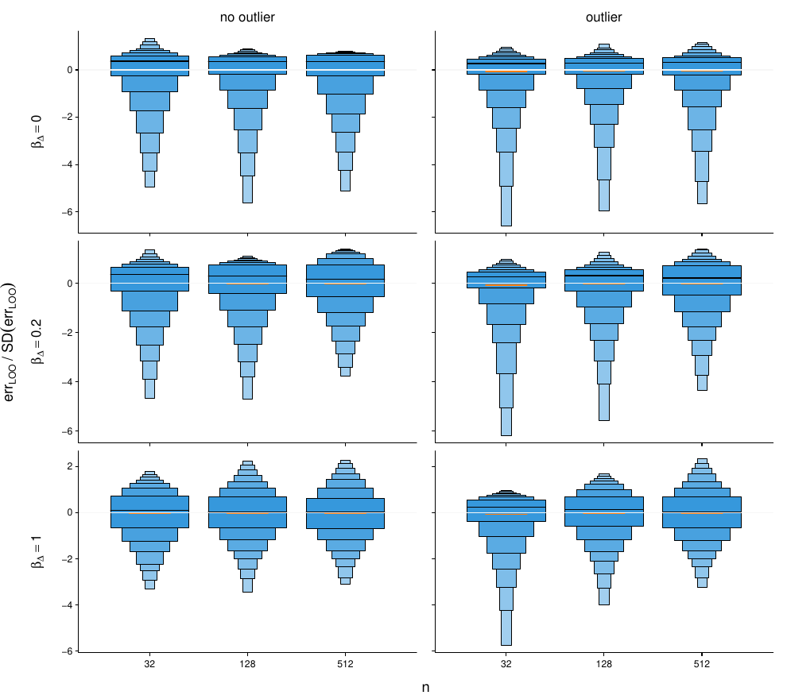

### t(5)

#### unknown variance

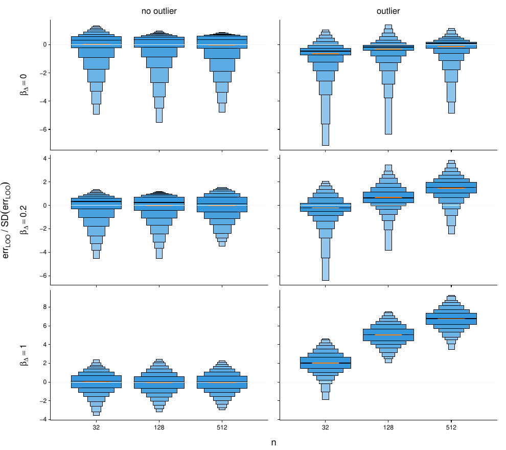

#### known variance (τ² = 1)

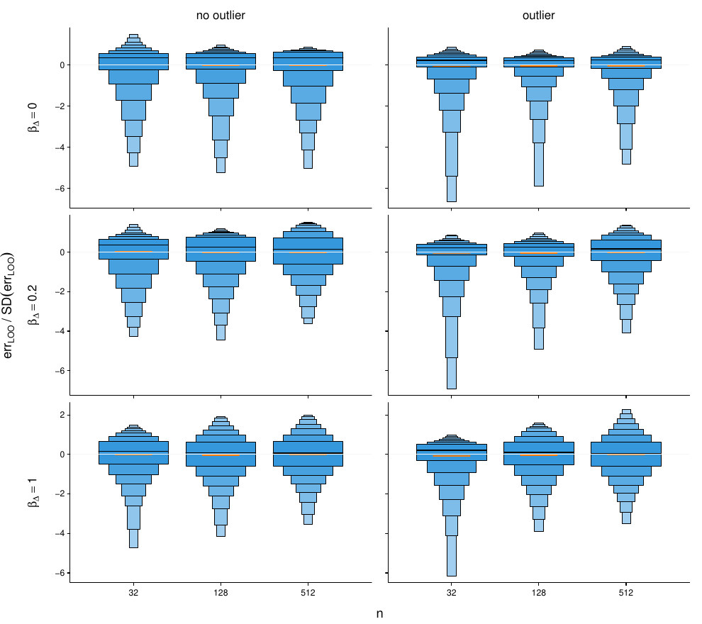

### t(3)

#### unknown variance

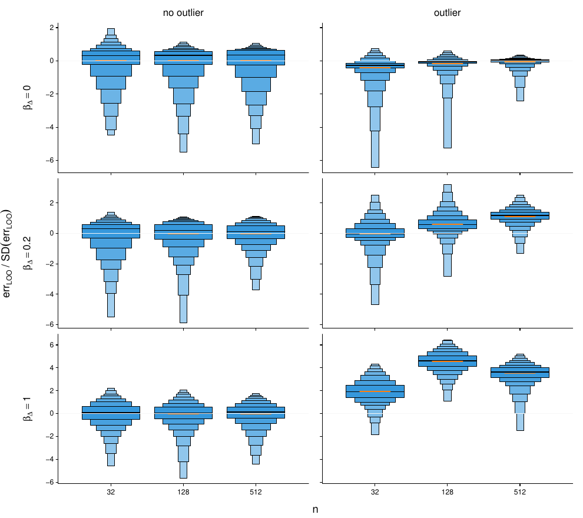

#### known variance (τ² = 1)

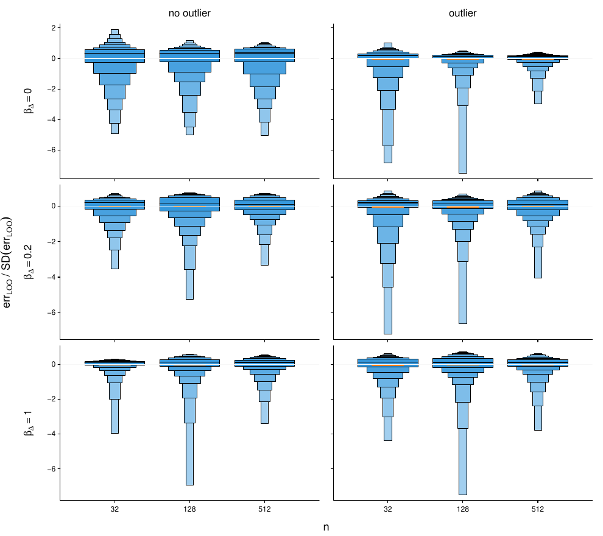

### t(1)

#### unknown variance

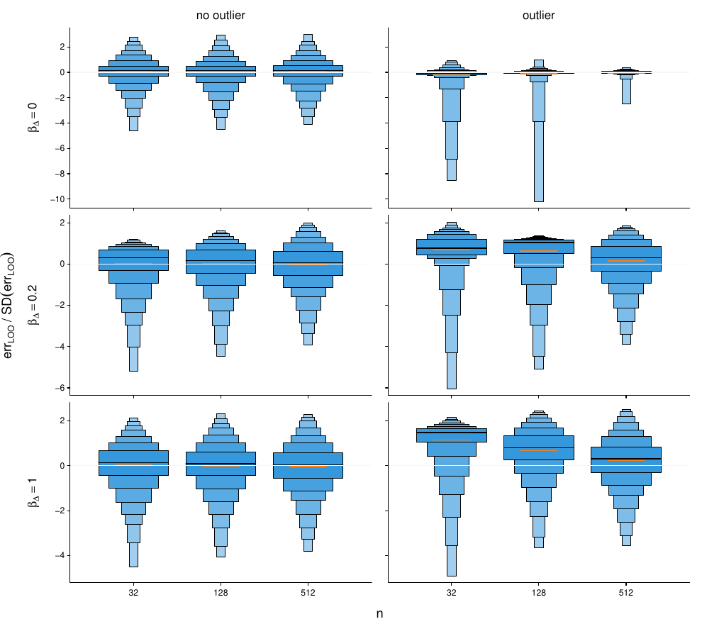

#### known variance (τ² = 1)

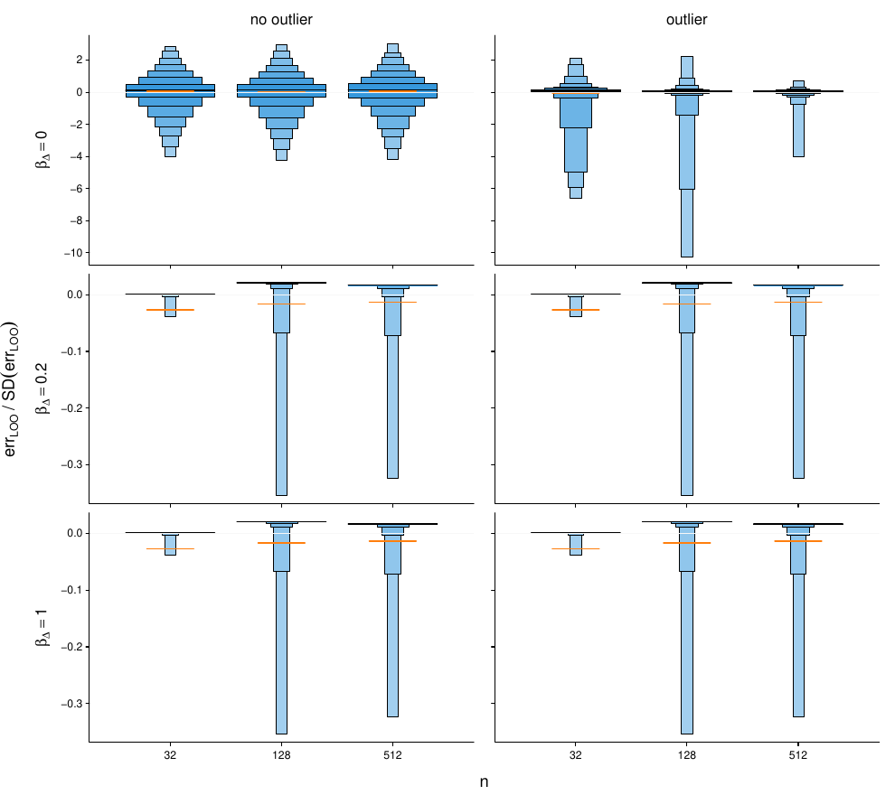